# Practical: fitting multispecies GLMMs and model diagnostics

Physalia workshop on GLLVMs

Bert van der Veen

# Background

So far, we have spoken a little about aspects of community ecological data, and learned about multispecies GLMs. In both cases, nested study designs are something that was encountered; plot-based sampling is very common in community ecology.

What we saw during the first practical, was that some of the species’ effects were very extreme. When we observe species in just a few environments, or only on a particular place on a gradient, the models can become very sure of themselves about where the species occurs. This gives extreme results, as we will also encounter in ordinations on Thursday. This also comes together with a load of uncertainty (remember the confidence intervals for some species were extremely wide for the VGLMs) because the effects will most likely change considerably if we resample the data. Makes sense when we have few observations, right?

Anyway, this practical is about random effects. As covered in the lecture, random effects have multiple purposes. One of them, is to “get rid” of effects that we are not interested in or consider unmeasured. This can be the case for variation in community composition due to a nested design, or variation due to repeated measurements. Random effects can also help to induce “shrinkage”; we assume that the random effects have a mean effect (the common effect for all species), so that if we do not have enough information for any particular species to estimate its effect, it reverts to the average of the whole community.

Random effects also offer great opportunities in estimating the variability or correlation of effects. Incorporating correlation into the modeling of multiple species was one of the original motivations for the introduction of GLLVMs to ecology, which you will learn more about tomorrow. In this practical we will fit GLMMs to data of multiple species, and try to make sense of the results.

# Data

I collected some datasets that we can work with, but if you have your own data you can also start by analyzing that instead. Today’s lecture used Wetlands (counts) and fungi (presence-absence, for the repeatability example); both are listed below.

1. Beetles (abundance)
2. Birds (presence-absence)
3. Wetlands (counts; used in the lecture)
4. wadden (abundance)
5. wadden (biomass)
6. fungi (presence-absence; used in the lecture)

Feel free to continue where you left off in the last exercises, for example with one of the datasets `mvabund` has:

1. “tasmania”: abundances of Copepod and Nematode species in a blocked design under a disturbance treatment
2. “antTraits”: abundance of 41 ant species, with environmental data
3. “solberg”: abundance of benthic invertebrate species with a variable of organic enrichment
4. “spider”: abundance of 12 wolf spider species with environmental variables
5. “tikus”: abundance of coral species over time

and there are more datasets (e.g., “dune”, “pyrifos”, “mite”, and “BCI”) in the `vegan` R-package.

# Part I

If you chose to work with a dataset that you did not work with during the last exercise, please make sure to start with some basic visualizations. I will continue with the waddensea data; it has a nested study design which makes it perfect for demonstrating the use of random effects.

```r
Y <- read.table("../../data/waddenY.csv", sep="," ,header=TRUE, row.names = 2)[,-1]
X <- read.table("../../data/waddenX.csv", sep=",", header=TRUE, row.names = 2)[,-1]
X <- X[,-which(apply(X,2, anyNA))] # remove column with NAs
```

As a matter of terminology, we speak of “random effects model” if only random effects are included, and “mixed-effects model” means that both random and fixed effects are included. As a framework, the latter includes the former.

In the last exercise, I fitted the model:

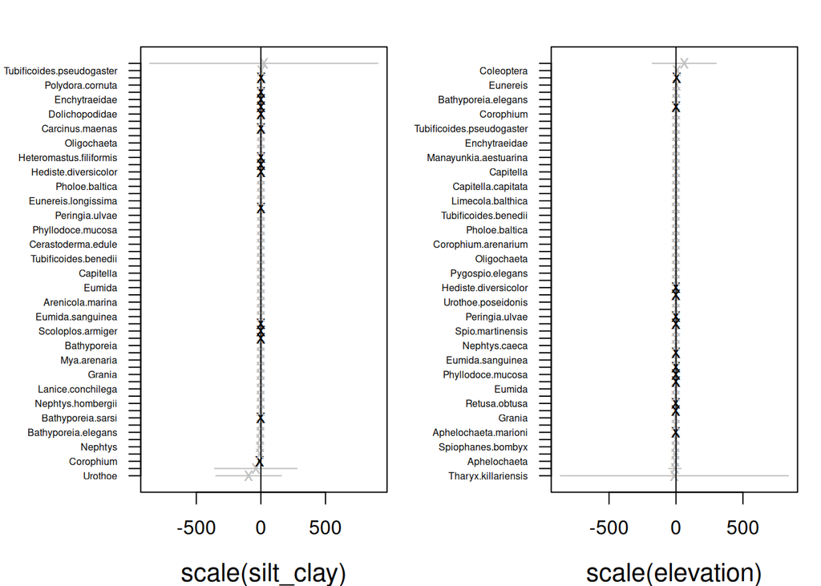

```r
library(gllvm)
model1 <- gllvm(Y, X, formula = ~scale(silt_clay) + scale(elevation), family = "negative.binomial", num.lv = 0)
coefplot(model1)
```

The caterpillar plots created with `coefplot` showed some extreme results: species with very large estimates and large confidence intervals. By specifying the effects as random, we can pull these closer to the average effect, reining their variability. Let’s go ahead and specify the equivalent of this model, but with random effects:

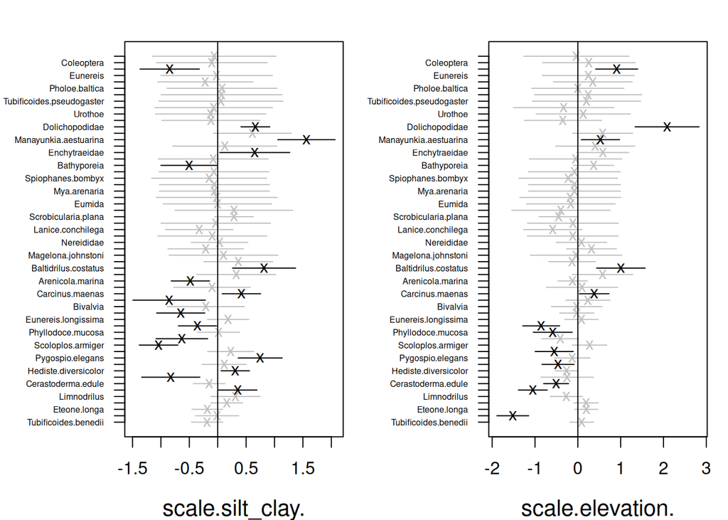

```r
model2 <- gllvm(Y, X, formula = ~(0+scale(silt_clay)|1) + (0+scale(elevation)|1), family = "negative.binomial", num.lv = 0)
randomCoefplot(model2)
```

The `randomCoefplot` function does essentially the same as `coefplot`, except that it plots random effects with *prediction* intervals. To understand what these are, let’s have a look at the following two equations:

$$\begin{equation}
\begin{aligned}
\beta_{kj} &\sim \mathcal{N}(\mu_k, \sigma^2_k)\\
\beta_{kj} &= \mu_k + b_{kj} \sim \mathcal{N}(0, \sigma^2_k)
\end{aligned}
\end{equation}$$

these two parameterisations are equivalent. The $\mu_k$ are the species-common effects per covariate $k$, and the $b_{kj}$ are the species’ deviation from that common effect. The $b_{kj}$ are what the `randomCoefPlot` function plots, so that they are relative to the common effect. If the prediction interval crosses zero, we have too little evidence to conclude that the species’ environmental response to the covariate is different from the common effect for all species. The common effect can be examined via the `summary`:

```r
summary(model2)
```

```
##
## Call:
## gllvm(y = Y, X = X, formula = ~(0 + scale(silt_clay) | 1) + (0 +
##     scale(elevation) | 1), family = "negative.binomial", num.lv = 0)
##
## Family:  negative.binomial
##
## AIC:  16722.68 AICc:  16725.81 BIC:  17580.44 LL:  -8241 df:  120
##
## Informed LVs:  0
## Constrained LVs:  0
## Unconstrained LVs:  0
##
## Formula:  ~(0 + scale(silt_clay) | 1) + (0 + scale(elevation) | 1)
## LV formula:  ~ 0
## Row effect:  ~ 1
##
##  Multispecies random effects:
##  Name             Variance Std.Dev
##  scale.silt_clay. 0.5558   0.7455
##  scale.elevation. 0.6292   0.7932
##
## Coefficients predictors:
##                  Estimate Std. Error z value Pr(>|z|)
## scale.silt_clay.   0.1458     0.1040   1.402   0.1609
## scale.elevation.  -0.1926     0.1124  -1.714   0.0864 .
## ---
## Signif. codes:  0 '***' 0.001 '**' 0.01 '*' 0.05 '.' 0.1 ' ' 1
```

Which also reports the estimates for the variances of the random effects. If these are (very) close to zero, the random effect can be omitted from the model, but in this case there is a good reason to include it for both covariates. Some people prefer keeping random effects with zero variance in the model, out of theoretical reasons. For example, in the case it is a variable that accounts for a nested design. However, in that case the model is equivalent to the model without the random effect, and calculated uncertainties for fixed effects will be more accurate when we omit the random effect, so omission has my (personal) preference.

By default, the (fixed) common effect is included with random effects in the `gllvm` package. However, it is controlled by `row.eff`, so we can exclude it if we want, or choose to include it only for particular covariates:

```r
model3 <- gllvm(Y, X, formula = ~(0+scale(silt_clay)|1) + (0+scale(elevation)|1), row.eff =~1, family = "negative.binomial", num.lv = 0)
summary(model3)
```

```
##
## Call:
## gllvm(y = Y, X = X, formula = ~(0 + scale(silt_clay) | 1) + (0 +
##     scale(elevation) | 1), family = "negative.binomial", num.lv = 0,
##     row.eff = ~1)
##
## Family:  negative.binomial
##
## AIC:  16723.29 AICc:  16726.32 BIC:  17566.76 LL:  -8244 df:  118
##
## Informed LVs:  0
## Constrained LVs:  0
## Unconstrained LVs:  0
##
## Formula:  ~(0 + scale(silt_clay) | 1) + (0 + scale(elevation) | 1)
## LV formula:  ~ 0
## Row effect:  ~ 1
##
##  Multispecies random effects:
##  Name             Variance Std.Dev
##  scale.silt_clay. 0.5758   0.7588
##  scale.elevation. 0.6660   0.8161
```

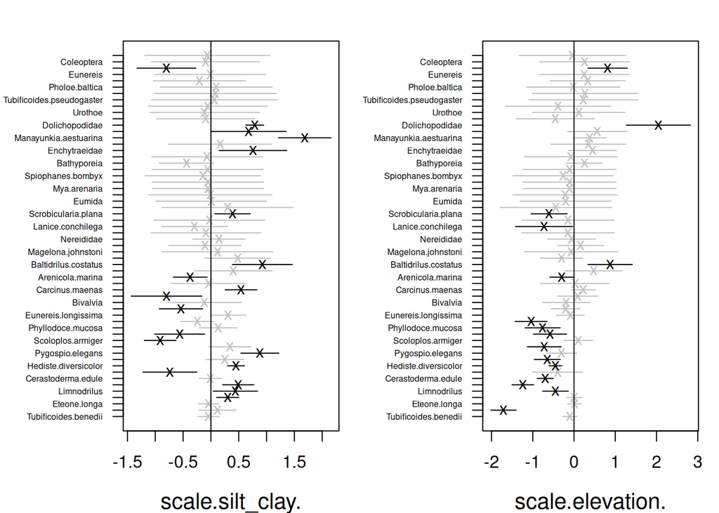

```r
randomCoefplot(model3)
```

We can then check with (for example) information criteria, if the model is improved when it is included:

```r
AIC(model2, model3)
```

```
##         df      AIC
## model2 120 16722.68
## model3 118 16723.29
```

It is marginally improved, as it turns out. The typical rule-of-thumb (Burnham and Anderson, 2002) is that per parameter AIC should improve by 2 points. Here, it has improved by about 1 point while we included 2 more parameters in the first model than the second. So, we can probably omit them. The consequence, is that species’ random effects will be centered around zero, so that on average the random effect has no effect on the community composition. This seems correct from the caterpillar plot of random coefficients, as most of the random effect estimates are greyed out.

The model above includes random slopes. However, as I mentioned, the dataset has a nested design; transects at islands, which we should incorporate. We can choose to include this as random effect in `formula` or in `row.eff`. The latter is a simplification of the former; it does not allow for correlation between random effects (only within random effects, such as due to spatial autocorrelation), and it assumes that all random effect estimates are the same for all species.

Let’s go ahead, fit these two models, and compare them. Note that this might take a little, as there are quite a few random effects to estimate: $3*58+58*2$ and another 58 fixed effects parameters for species’ intercepts (which are included by default). If we instead formulated the random effect below as transect/island, the number of random effects would instead be $3*3*58+58*2$ (as there are also 3 transects). There are some ways to speed this up, but we will consider those tomorrow instead. By default, the package includes correlations between the different categories of the same random effect, which we (for now) omit using `diag`.

```r
model4 <- gllvm(Y, X, formula = ~diag(0+island|1) + (0+scale(silt_clay)|1) + (0+scale(elevation)|1), row.eff =~1, family = "negative.binomial", num.lv = 0)
model5 <- gllvm(Y, studyDesign=X, row.eff = ~(1|island), family = "negative.binomial", num.lv = 0)
```

The “model5” treats island as a species-common random intercept instead of the species-specific version in “model4”, and drops the silt_clay/elevation random slopes entirely. We can go ahead and compare them with AIC:

```r
AIC(model4, model5)
```

```
##         df      AIC
## model4 121 16567.09
## model5 117 16994.62
```

Although there are technically only a few parameters more in “model4” than “model5”, we have to keep in mind that “model4” has many more (species-specific) random effects. So, we did expect “model4” to be considerably better, despite the fact that “model5” with species-common random effects is a much simpler model.

Although we have now specified all effects as random, we are of course free to combine random and fixed effects at will, for example:

```r
model6 <- gllvm(Y, X, formula = ~diag(0+island|1) + scale(silt_clay) + scale(elevation), row.eff =~1, family = "negative.binomial", num.lv = 0)
```

Whether we include an effect as random or as fixed requires careful deliberation. Inducing shrinkage can result in (too) conservative estimates if we do not have enough data. When we have enough data, results of the two will (at least in this particular instance) be very similar; the random effect will then act like a fixed effect.

One of the benefits of maintaining an effect as random, is that we can calculate diversity for our system directly from the model — this connects to the alpha/beta/gamma diversity framework covered in Wednesday’s Diversity lecture, but we can get a first taste of it already here. We can also predict how diversity changes along a gradient. For the model above with silt_clay and elevation as random effects, alpha diversity is:

$$\begin{equation}
\text{var}(\eta_{ij}) = elevation_i^2\sigma^2_{elevation} +
silt_clay_i^2\sigma^2_{silt_clay}.
\end{equation}$$

Which tells us that we can visualize the change in alpha diversity due to one of the covariates, by keeping the other constant. For example, for elevation:

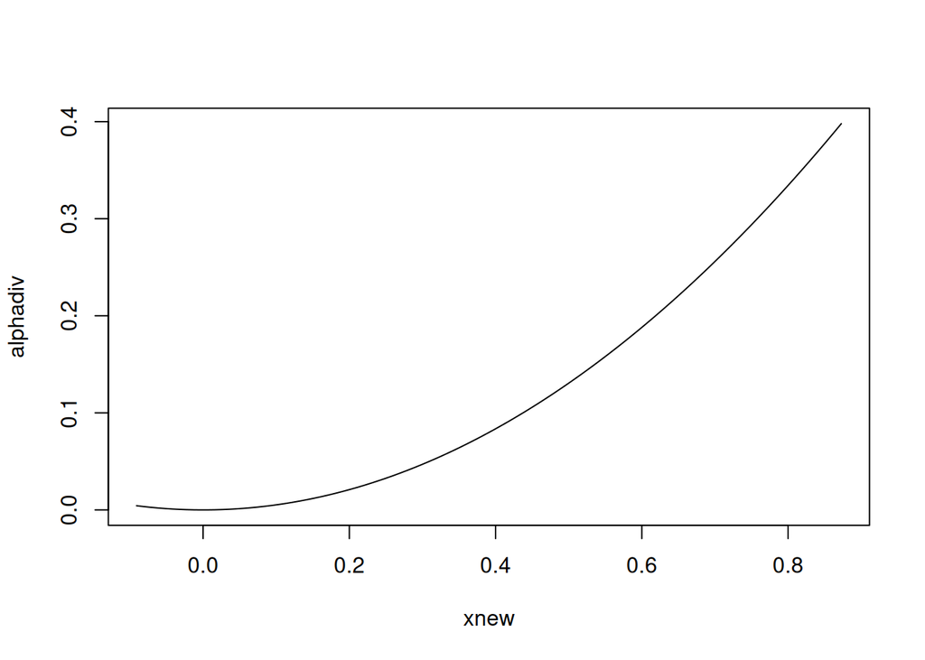

```r
xnew <- seq(min(scale(X$elevation)), max(scale(X$elevation)), length.out = 100)
std <- sqrt(diag(model4$params$sigmaB)[5])
alphadiv <- (xnew*std*sd(X$elevation)+mean(X$elevation)*std)^2
xnew <- xnew*sd(X$elevation)+mean(X$elevation)
plot(xnew, alphadiv, type = "l") # backtransform
```

so that alpha diversity increases with elevation.

## Tasks

1. Fit models with random intercepts and/or random slopes, to get a hang on the syntax.
2. Try both standardized and centered covariates, as well as uncentered and unscaled. How does it affect the model?
3. Experiment with fixed and random effects in the model; which one performs better for your chosen dataset?
4. Try to build an ecological understanding of variance parameters in terms of diversity and turnover

# Part II

So far, we have fitted random effects models where the random effects are independent (have no correlation). Especially when it comes to shrinkage, or when we do not have so much information, this is a sensible thing to do. It requires quite a lot of information to estimate correlation parameters, where with “information” I mean “levels of the random effect”. In our case, the number of species represent the number of replicates for the random effect that we have. Fortunately, we often have a bunch of them! So, we can probably go ahead and estimate the correlation of random effects.

Ecologically, correlation of random effects corresponds best with *trait syndromes*, where species’ environmental responses are a type of latent trait. Positive correlation of random effects means that a species’ response to one effect is similar to that of another, and negative that they are opposites. If the correlation is close to zero, a species’ response to two effects is entirely different.

Syntax-wise, terms that share the same brackets get correlation parameters; simple, right?! It is important to note that the number of correlation parameters increases quite quickly with the number of effects, and that it tends to slow model fitting down considerably, due to the added complexity. Having said that, let’s go ahead and add a correlation parameter for silt_clay and elevation:

```r
model8 <- gllvm(Y, X, formula = ~diag(0+island|1) + (0+scale(silt_clay)+scale(elevation)|1), row.eff =~1, family = "negative.binomial", num.lv = 0)
summary(model8)
```

```
##
## Call:
## gllvm(y = Y, X = X, formula = ~diag(0 + island | 1) + (0 + scale(silt_clay) +
##     scale(elevation) | 1), family = "negative.binomial", num.lv = 0,
##     row.eff = ~1)
##
## Family:  negative.binomial
##
## AIC:  16563.99 AICc:  16567.23 BIC:  17436.05 LL:  -8160 df:  122
##
## Informed LVs:  0
## Constrained LVs:  0
## Unconstrained LVs:  0
##
## Formula:  ~diag(0 + island | 1) + (0 + scale(silt_clay) + scale(elevation) | 1)
## LV formula:  ~ 0
## Row effect:  ~ 1
##
##  Multispecies random effects:
##  Name             Variance Std.Dev Corr
##  islandNorderney  2.2518   1.5006
##  islandSpiekeroog 0.0000   0.0006  0.0000
##  islandWangerooge 0.3175   0.5635  0.0000 0.0000
##  scale.silt_clay. 0.3041   0.5515  0.0000 0.0000 0.0000
##  scale.elevation. 0.2741   0.5235  0.0000 0.0000 0.0000 0.4401
```

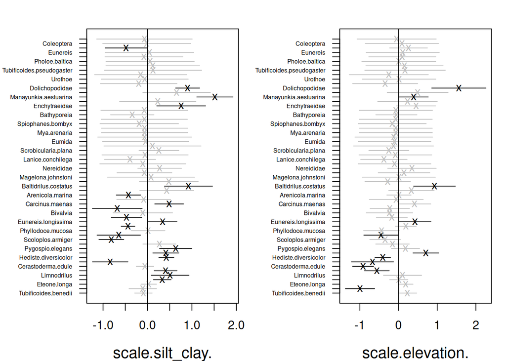

```r
randomCoefplot(model8, which.Xcoef = c("scale.silt_clay.", "scale.elevation."))
```

We do see similarity: some of species’ responses to silt_clay are almost the same as for elevation. If the correlation parameter had been very close to 1, we would have been looking at two nearly duplicate plots.

We can introduce a few more correlation parameters, by removing the `diag` around the island covariate, and then construct a correlogram for a quicker overview than that `summary` gives us. If you are using the same dataset as I am, the following model will take a bit to run, as there are 10 correlation parameters now included.

```r
model9 <- gllvm(Y, X, formula = ~(0+island+scale(silt_clay)+scale(elevation)|1), row.eff =~1, family = "negative.binomial", num.lv = 0)
```

Woops, it did not converge; the numerical optimiser reached the maximum number of iterations. Let’s increase this and try again:

```r
model9 <- gllvm(Y, X, formula = ~(0+island+scale(silt_clay)+scale(elevation)|1), row.eff =~1, family = "negative.binomial", num.lv = 0, control = list(maxit = 10e3))
summary(model9)
```

```
##
## Call:
## gllvm(y = Y, X = X, formula = ~(0 + island + scale(silt_clay) +
##     scale(elevation) | 1), family = "negative.binomial", num.lv = 0,
##     row.eff = ~1, control = list(maxit = 10000))
##
## Family:  negative.binomial
##
## AIC:  16538.19 AICc:  16541.93 BIC:  17474.59 LL:  -8138 df:  131
##
## Informed LVs:  0
## Constrained LVs:  0
## Unconstrained LVs:  0
##
## Formula:  ~(0 + island + scale(silt_clay) + scale(elevation) | 1)
## LV formula:  ~ 0
## Row effect:  ~ 1
##
##  Multispecies random effects:
##  Name             Variance Std.Dev Corr
##  islandNorderney  1.1765   1.0847
##  islandSpiekeroog 0.5236   0.7236  -0.8808
##  islandWangerooge 0.3087   0.5556  -0.6849  0.2842
##  scale.silt_clay. 0.2711   0.5207  -0.0723  0.1162 -0.2840
##  scale.elevation. 0.2887   0.5373   0.0267 -0.0544 -0.1771  0.4520
```

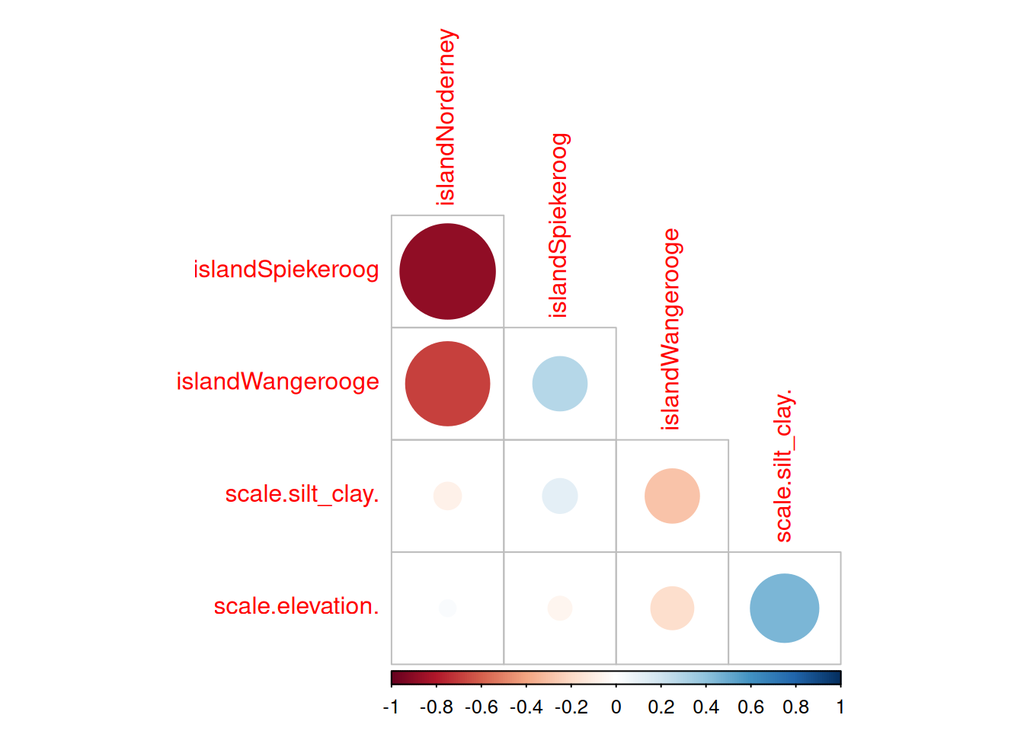

```r
cors <- cov2cor(model9$params$sigmaB)
colnames(cors) <- row.names(cors) <- colnames(model9$params$sigmaB)
corrplot::corrplot(cors, type = "lower", diag = FALSE)
```

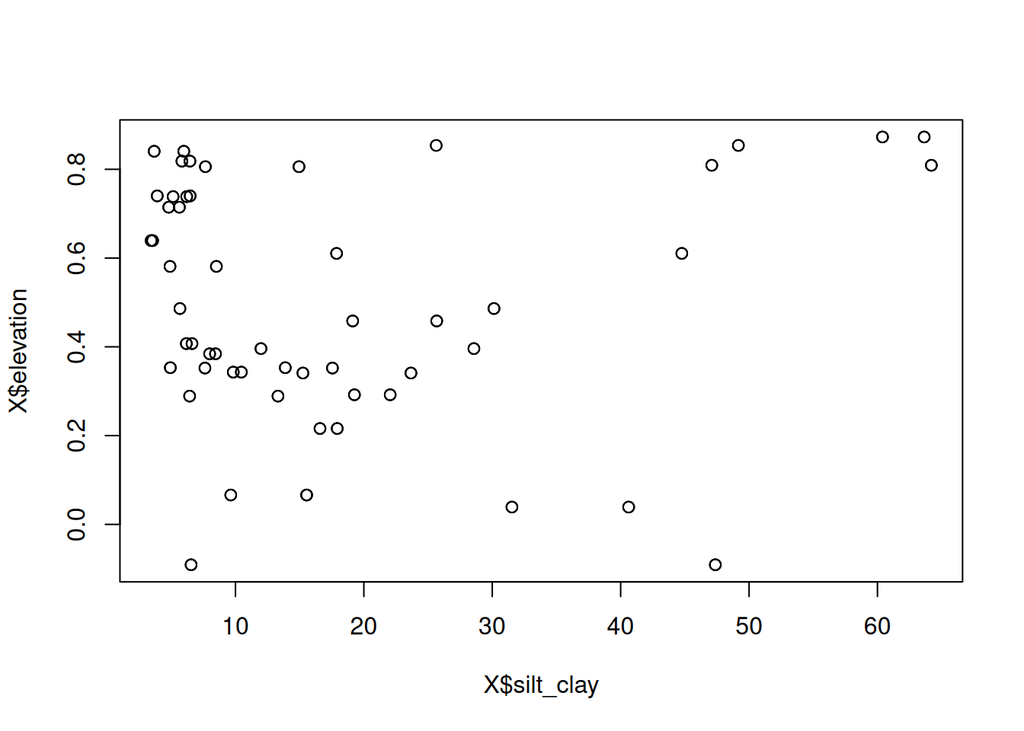

```r
plot(X$silt_clay, X$elevation)
```

## ICC and repeatability

Variance components also let us compute the intraclass correlation (ICC): the fraction of variance attributable to a particular random effect grouping. Using the variance components already estimated in `model4` (species-specific island effects, and random slopes for silt_clay and elevation):

```r
sigmaB <- diag(model4$params$sigmaB)
names(sigmaB) <- colnames(model4$params$sigmaB)
sigmaB / sum(sigmaB)
```

```
##  islandNorderney islandSpiekeroog islandWangerooge scale.silt_clay.
##     0.4781334151     0.0002861587     0.1733147140     0.1818769549
## scale.elevation.
##     0.1663887573
```

This shows what fraction of the explained variance in the linear predictor is due to island, versus to the silt_clay and elevation slopes. A high ICC for island would mean that community composition is driven more by which island a sample came from than by the measured environmental gradients.

Repeatability extends the same idea by also including the residual (observation-level) variance in the denominator, so it answers “how much of the total variation, sampling noise included, is explained by this grouping?” rather than “how much of the explained variance is due to it?” For a negative binomial model the residual variance depends on the mean and dispersion parameter, so repeatability has to be evaluated species by species rather than as a single community-wide number.

## Tasks

1. Include correlation parameters between some (or all) of the terms in your model
2. Can you make ecological sense of the estimates for the correlation parameters?
3. Try to change the model a bit and see if different fixed and random effects, or different independent random effect terms, have a large impact on the sign (minus or plus) of the correlation parameters (i.e., a little sensitivity analysis)
4. Compute the ICC for `island` in `model4`. Is community composition dominated by island identity, or by the environmental slopes?
5. Pick one species and estimate its repeatability for island (include the residual variance implied by its dispersion parameter). How does it compare to the community-average ICC?

# Part III

So far we focused on random effects that account for variation between species. Let’s turn to random effects for the sites or samples themselves. The waddensea data are collected from three islands (Norderney, Spiekeroog, Wangerooge), with three transects (A, B, C) at each island, and three sampling stations within each transect. At each station, three samples were taken in spring and summer.

```r
head(X[,1:4], 12)
```

```
##                       island transect station season
## Nor_TA_II_spr_148  Norderney        A      II spring
## Nor_TA_II_spr_147  Norderney        A      II spring
## Nor_TA_II_spr_146  Norderney        A      II spring
## Nor_TA_II_sum_58   Norderney        A      II summer
## Nor_TA_II_sum_57   Norderney        A      II summer
## Nor_TA_II_sum_56   Norderney        A      II summer
## Nor_TA_III_spr_143 Norderney        A     III spring
## Nor_TA_III_spr_145 Norderney        A     III spring
## Nor_TA_III_spr_144 Norderney        A     III spring
## Nor_TA_III_sum_54  Norderney        A     III summer
## Nor_TA_III_sum_55  Norderney        A     III summer
## Nor_TA_III_sum_53  Norderney        A     III summer
```

Continuing from `model3` above: accounting for transect and station with species-specific random effects becomes too complex, since the number of unique sampling locations (stations with unique coordinates) is 3x3x3 = 27. A simpler way to account for the possible dependency between samples from the same location is to introduce a random effect common to all species. Let’s build a study design data frame. Island and season only have three and two levels respectively, which is not enough to estimate their variance properly if treated as a species-specific random effect; they are better handled with community-level effects for island and season instead:

```r
StudyDesign <- data.frame(X[,1:4], sample = rownames(X))
model10 <- gllvm(Y, X, formula = ~(0+scale(silt_clay)|1) + (0+scale(elevation)|1),
                 studyDesign = StudyDesign,
                 row.eff = ~(1|island:transect) + (1|island:transect:station) + (1|sample) + island + season,
                 family = "negative.binomial", num.lv = 0)
```

The fixed effects from `summary`:

```r
summary(model10)
```

```
##
## Call:
## gllvm(y = Y, X = X, formula = ~(0 + scale(silt_clay) | 1) + (0 +
##     scale(elevation) | 1), family = "negative.binomial", num.lv = 0,
##     studyDesign = StudyDesign, row.eff = ~(1 | island:transect) +
##         (1 | island:transect:station) + (1 | sample) + island +
##         season)
##
## Family:  negative.binomial
##
## AIC:  16637.05 AICc:  16640.4 BIC:  17523.41 LL:  -8195 df:  124
##
## Informed LVs:  0
## Constrained LVs:  0
## Unconstrained LVs:  0
##
## Formula:  ~(0 + scale(silt_clay) | 1) + (0 + scale(elevation) | 1)
## LV formula:  ~ 0
## Row effect:  ~(1 | island:transect) + (1 | island:transect:station) + (1 | sample) + island + season
##
##  Multispecies random effects:
##  Name             Variance Std.Dev
##  scale.silt_clay. 0.6216   0.7884
##  scale.elevation. 0.6458   0.8036
##
##  Random effects:
##  Name                                Variance Std.Dev
##  (Intercept)|island:transect         0.0000   0.0004
##  (Intercept)|island:transect:station 0.0903   0.3004
##  (Intercept)|sample                  0.0000   0.0008
##
## Coefficients predictors:
##                  Estimate Std. Error z value Pr(>|z|)
## islandSpiekeroog -0.52724    0.18329  -2.877 0.004020 **
## islandWangerooge -0.43920    0.19972  -2.199 0.027876 *
## seasonsummer      0.23592    0.06514   3.622 0.000293 ***
## ---
## Signif. codes:  0 '***' 0.001 '**' 0.01 '*' 0.05 '.' 0.1 ' ' 1
```

show that abundance overall is higher in summer than spring, and lower in Spiekeroog and Wangerooge than in Norderney.

Variation between transects, stations, and samples shows up in the standard deviations of the random effects:

```r
model10$params$sigma
```

```
##         (Intercept)|island:transect (Intercept)|island:transect:station
##                        0.0003794511                        0.3004469075
##                  (Intercept)|sample
##                        0.0008081842
```

```r
confint(model10, parm = "sigma")
```

```
##                                                 cilow       ciup
## sigma.(Intercept)|island:transect         -0.03305874 0.03381764
## sigma.(Intercept)|island:transect:station  0.18554537 0.41534844
## sigma.(Intercept)|sample                  -0.05509536 0.05671173
```

Community-level variation in abundance between transects and between samples is small (the standard deviations are close to zero) once all levels of the sampling design are accounted for along with silt_clay and elevation. There is, however, some variation between stations.

## Tasks

1. Include random effects that account for the sampling design in your model.
2. Compare a model with community-level random effects for the sampling design to one without. Does it change the fixed-effect estimates or their uncertainty?

# Technical caveats

Mixed-effects models come with technical caveats that are easy to overlook. Work through the following for your fitted models.

## Hypothesis testing

The Wald statistics and $p$-values reported by `summary()` are approximate. For fixed effects, they rely on a normal approximation that works well for large samples but can be misleading when random effects are estimated with few levels.

**Questions:**

1. Fit a model with a fixed covariate. Note its Wald $p$-value. Does it change when you switch the effect from fixed to random? What does this tell you?
2. Try testing $H_0: \sigma^2 = 0$ using a likelihood ratio test (`anova()` or comparing `AIC`). What happens? (Hint: look up the “boundary problem” for variance testing.)

## Model selection

`AIC()` works for comparing models fitted with the same method, but there is a subtlety: `gllvm` always fits by (marginal) maximum likelihood, it does not implement a REML-corrected likelihood. That means AIC comparisons of models differing only in a random-effect variance are subject to the same boundary problem as the likelihood ratio test above, and should be interpreted cautiously.

**Questions:**

3. Compare two models that differ only in a fixed effect using AIC. Now compare two models that differ only in a random-effect variance (as in the previous question). Which comparison do you trust more, and why?
4. What is the penalty for including a random slope vs. a fixed slope in terms of AIC? Does AIC favour the simpler model when $\hat\sigma^2 \approx 0$?

# Residual diagnostics

Residual diagnostics are covered in depth in the **Checking** lecture; here is a worked example on this practical’s own data. `gllvm` objects have a `plot` method that produces five diagnostic plots from the Dunn-Smyth (randomized quantile) residual: residuals vs. linear predictors, a normal QQ-plot, residuals vs. rows, residuals vs. columns, and a scale-location plot.

Suppose we had not accounted for overdispersion, and fitted `model1` with a Poisson distribution instead of negative binomial:

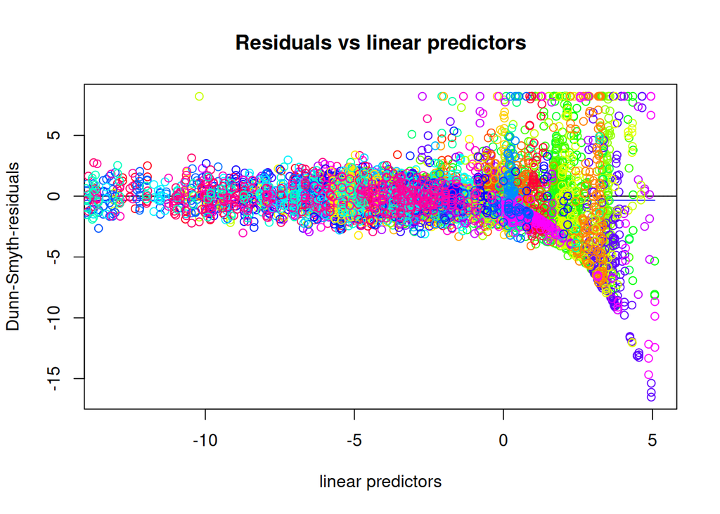

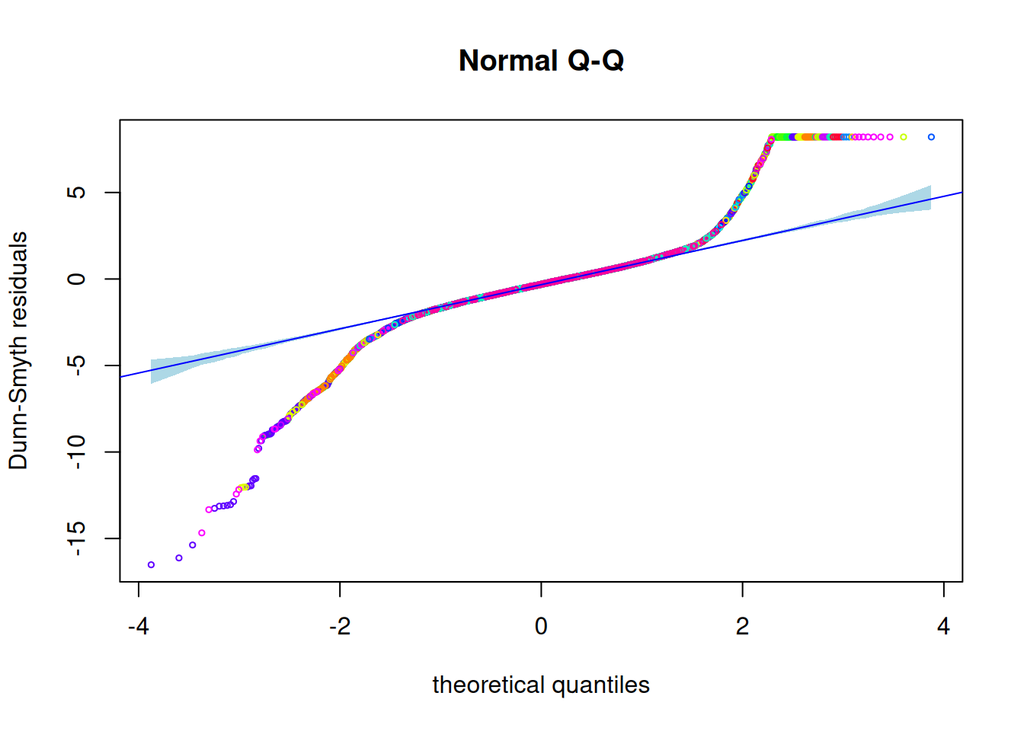

```r
model_pois <- gllvm(Y, X, formula = ~scale(silt_clay) + scale(elevation), family = "poisson", num.lv = 0)
plot(model_pois, which = c(1, 2))
```

The QQ-plot shows heavy departure in the tails, and the residuals-vs-fitted plot fans out: both point at overdispersion, i.e. the Poisson variance function (mean = variance) is too restrictive for this data. Compare this to `model1`, which uses the negative binomial:

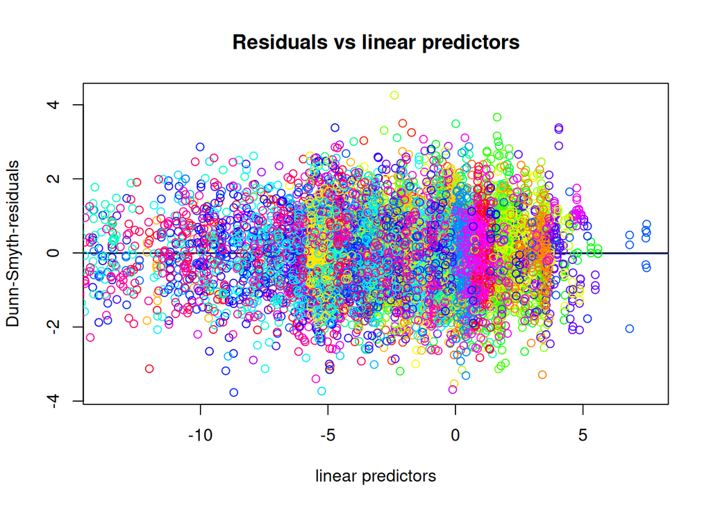

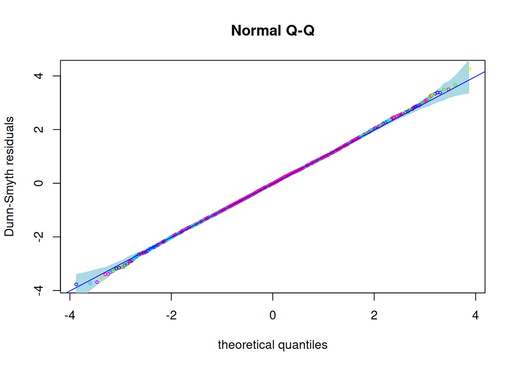

```r
plot(model1, which = c(1, 2))
```

No systematic pattern remains: the QQ-plot tracks the diagonal, and the fan pattern is gone. That does not make `model1` the “correct” model, only one whose distributional assumption is no longer visibly violated.

For VGLMMs it is also worth checking the normality of the estimated random effects, for example for `model2`’s species-specific silt_clay and elevation slopes (stored in `params$Br`):

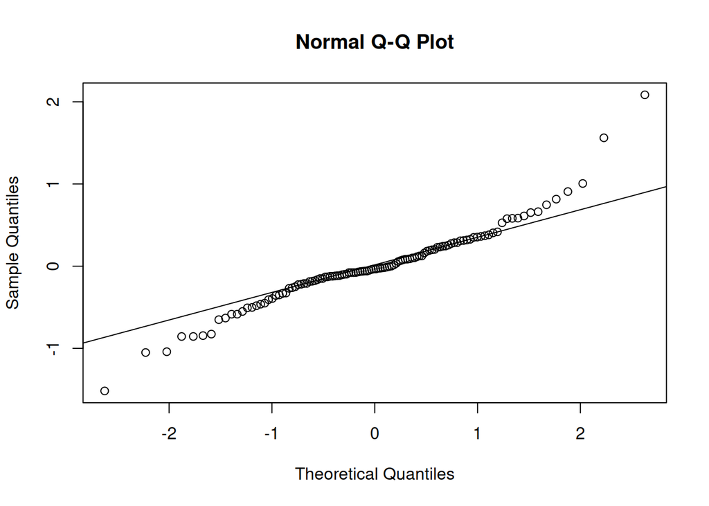

```r
qqnorm(as.vector(model2$params$Br))
qqline(as.vector(model2$params$Br))
```

**Questions:**

5. Reproduce the Poisson-vs-negative-binomial comparison above for one of your own fitted models. Which of the five diagnostic plots first reveals the misspecification?
6. Do the estimated random effects look normally distributed? What would a long-tailed distribution suggest about the random effects assumption?

See the Checking lecture for a full treatment of conditional vs. unconditional residuals and what violations look like.